# Gráficos Estadísticos en R

# 1 Gráficos para una variable

## 1.1 Histograma

Muestra de manera razonable la forma de la distribución de una variable. La creación de este gráfico consiste en contar la cantidad de observaciones que caen dentro de divisiones específicas (*bins*) y mostrar esta longitud por medio de barras.

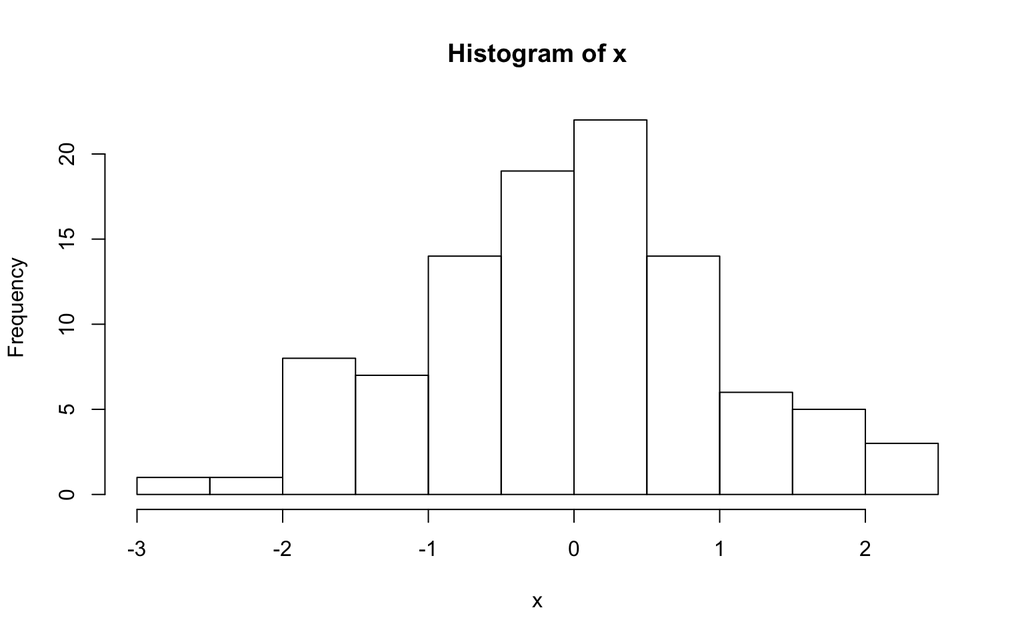

```r
# Creamos un conjunto de 100 datos provenientes de una distribución normal estándar
x <- rnorm(n = 100)

# Graficamos el Histograma
hist(x) # Gráfico por defecto
```

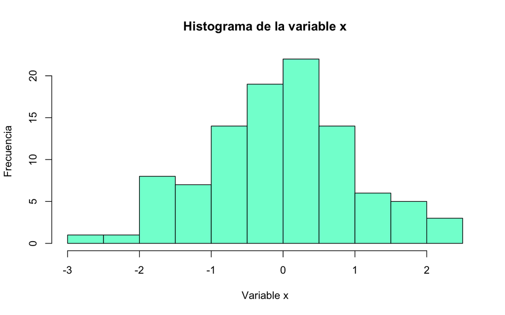

```r
# Personalizando el histograma
hist(x,
     col = "aquamarine", # se especifica el color
     main = "Histograma de la variable x", # se especifica el título
     xlab = "Variable x", # nombre para el eje X
     ylab = "Frecuencia" # nombre para el eje Y
    )
```

**Nota:** Los colores se pueden especificar por sus nombres en inglés. En R, existen 657 nombres que se pueden observar mediante la función `colors()`.

```r
# Los primeros colores
head(colors())
```

```
[1] "white"         "aliceblue"     "antiquewhite"  "antiquewhite1"
[5] "antiquewhite2" "antiquewhite3"
```

## 1.2 Gráfico de Densidad

Visualiza la distribución de los datos estimando una densidad mediante metodologías no paramétricas llamadas estimaciones de densidad de kernel.

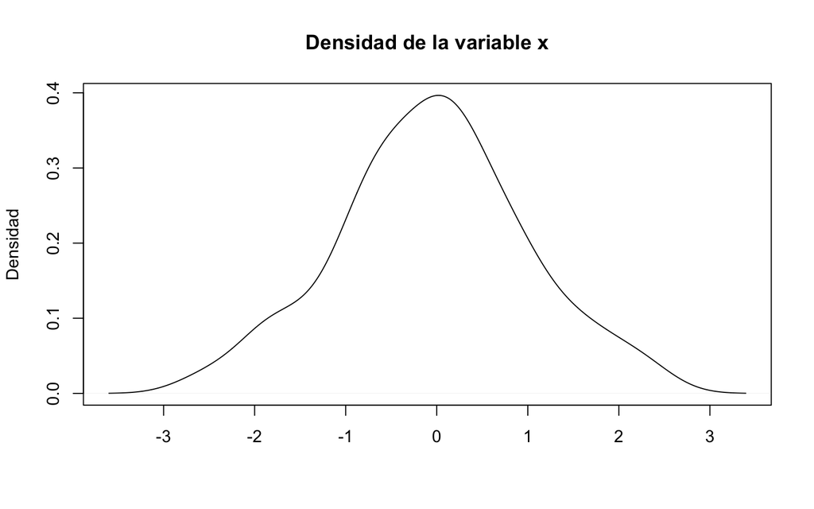

```r
plot(density(x), main = "Densidad de la variable x", xlab = " ", ylab = "Densidad")
```

### 1.2.1 Función de densidad de distribuciones conocidas

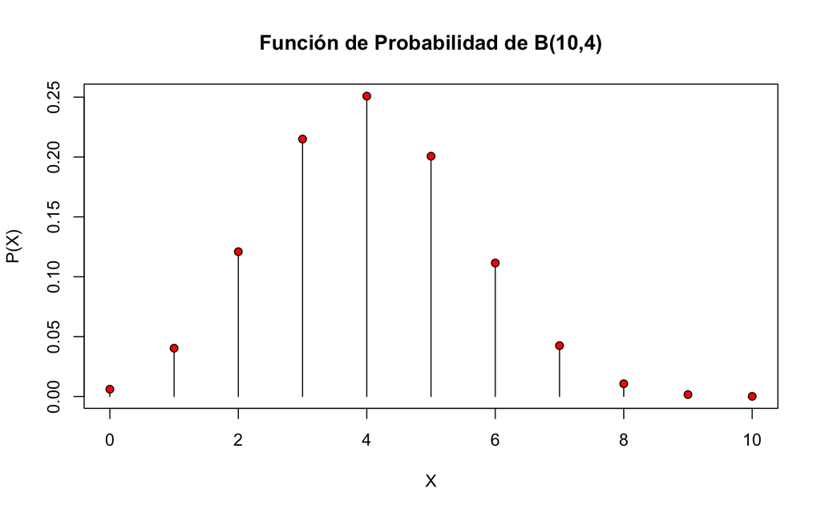

```r
# Distribución Binomial
# X ~ B(n = 10, p = 0.4)
x <- 0:10
px <- dbinom(x = x, size = 10, prob = 0.4)

# Función de Probabilidad
plot(x, px, type = "h", xlab = "X", ylab = "P(X)",
     main = "Función de Probabilidad de B(10,4)")
# Añadiendo puntos
points(x, px, pch = 21, bg = "red")
```

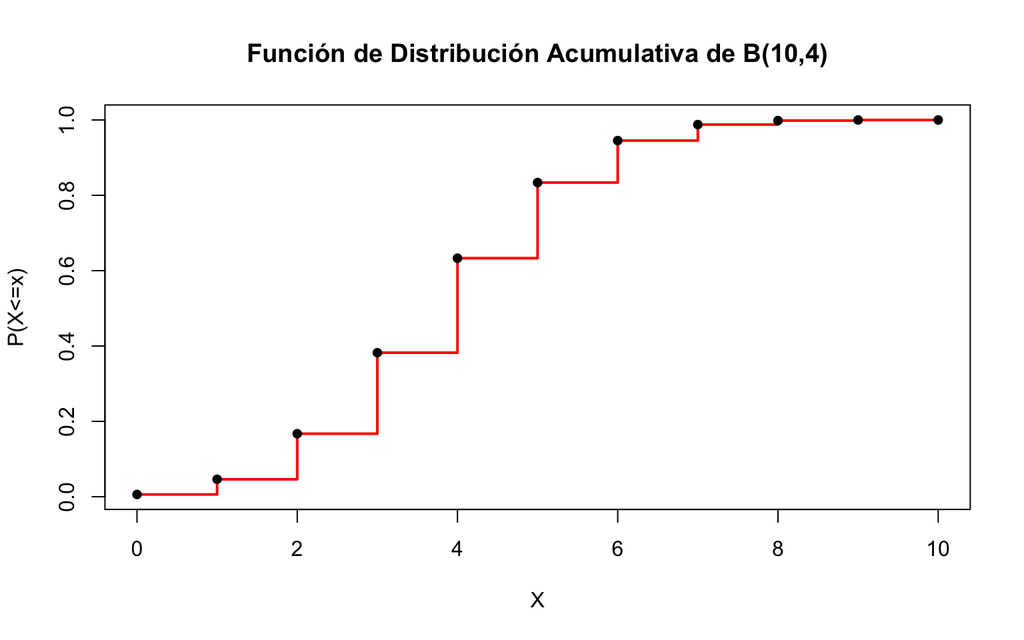

```r
# Probabilidades Acumuladas
pacumx <- pbinom(q = x, size = 10, prob = 0.4)
# Función de Distribución Acumulativa
plot(x, pacumx, type = "s", # Función escalera (horizontal a vertical)
     col = "red", lwd = 2,
     xlab = "X", ylab = "P(X<=x)",
     main = "Función de Distribución Acumulativa de B(10,4)")
# Añadiendo puntos
points(x, pacumx, pch = 16, bg = "black")
```

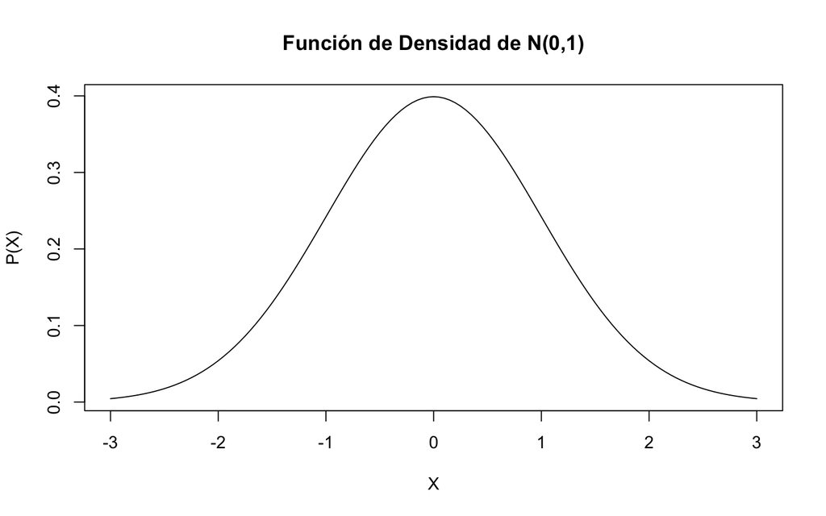

```r
# Distribución Normal X ~ N(0,1)
x <- seq(-3, 3, 0.05)
px <- dnorm(x, mean = 0, sd = 1)

# Función de densidad
plot(x, px, type = "l", xlab = "X", ylab = "P(X)", main = "Función de Densidad de N(0,1)")
```

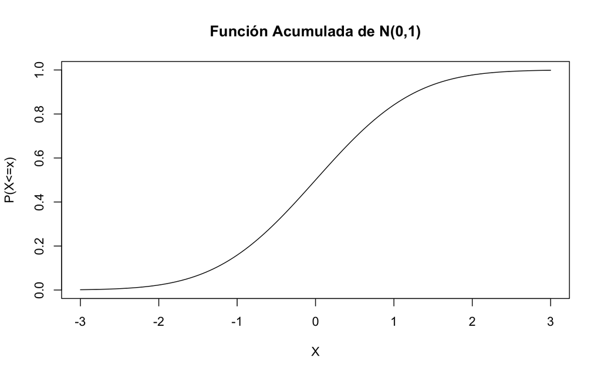

```r
# Probabilidades Acumuladas
pacumx <- pnorm(q = x, mean = 0, sd = 1)
# Función de Distribución Acumulativa
plot(x, pacumx, type = "l", xlab = "X", ylab = "P(X<=x)", main = "Función Acumulada de N(0,1)")
```

## 1.3 Diagrama de Cajas o Boxplot

Permite mostrar la simetría de la distribución de los datos y su construcción está basada principalmente en la mediana, cuartiles y valores extremos.

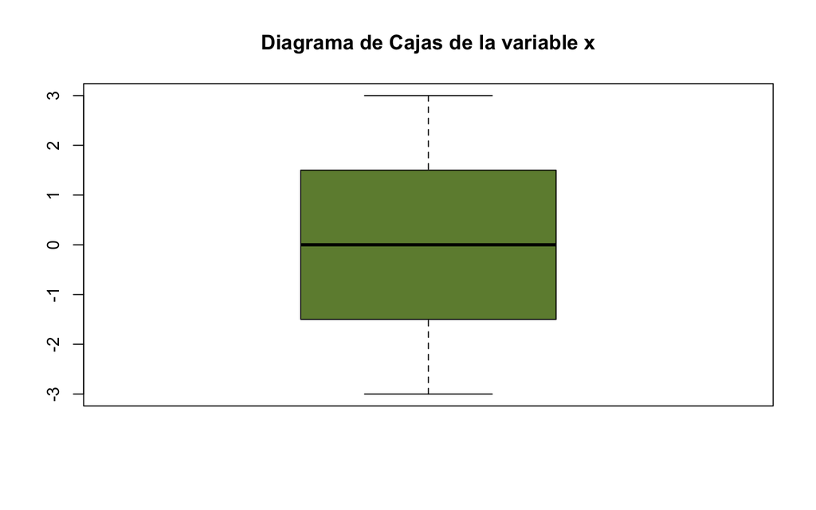

```r
boxplot(x, main = "Diagrama de Cajas de la variable x", col = "darkolivegreen4")
```

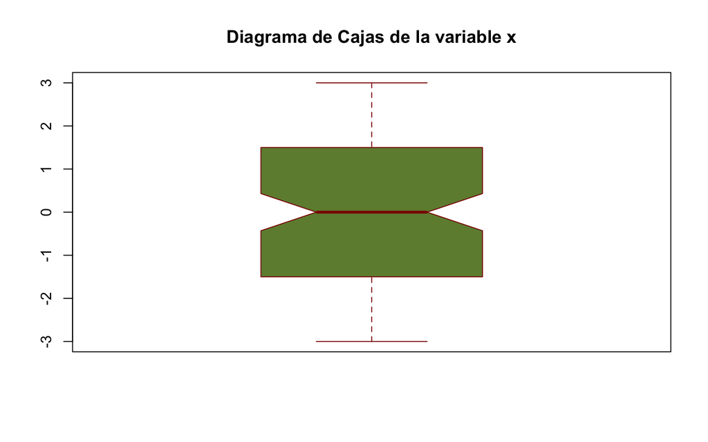

```r
# Personalizando con mayores detalles
boxplot(x, main = "Diagrama de Cajas de la variable x",
        col = "darkolivegreen4", # Color de relleno
        border = "darkred", # Color del borde
        outline = FALSE, # No se grafican los outliers
        notch = TRUE # La caja tiene cortes hacia adentro en la mediana
        )
```

## 1.4 Gráfico de Barras

Visualiza la frecuencia (cantidad de elementos), por medio de barras verticales, que ocurren en las diferentes categoría de una variable.

Para introducir este tipo de gráfico, se propone una lista de alumnos ingresantes a las carreras de Ingeniería Estadística, Ingeniería Económica, Ingeniería Industrial e Ingeniería de Sistemas, la cual es registrada en un *data frame* llamado ingresantes.

```r
alumnos <- c("Luis", "Romina", "Alicia", "Javier", "Melisa", "Amanda", "Jesús",
    "Diego", "Alonso", "Gabriel", "Gerardo", "Viviana", "Rodrigo", "Sofía",
    "Raúl", "David")

escuela <- rep(c("Estadística", "Económica", "Sistemas", "Industrial"), c(7,
    3, 2, 4))

# Se juntan la información
ingresantes <- data.frame(alumnos, escuela)
ingresantes  # Se muestran los datos
```

```
   alumnos     escuela
1     Luis Estadística
2   Romina Estadística
3   Alicia Estadística
4   Javier Estadística
5   Melisa Estadística
6   Amanda Estadística
7    Jesús Estadística
8    Diego   Económica
9   Alonso   Económica
10 Gabriel   Económica
11 Gerardo    Sistemas
12 Viviana    Sistemas
13 Rodrigo  Industrial
14   Sofía  Industrial
15    Raúl  Industrial
16   David  Industrial
```

```r
# Estructura de la información
str(ingresantes)
```

```
'data.frame':   16 obs. of  2 variables:
 $ alumnos: Factor w/ 16 levels "Alicia","Alonso",..: 10 14 1 8 11 3 9 5 2 6 ...
 $ escuela: Factor w/ 4 levels "Económica","Estadística",..: 2 2 2 2 2 2 2 1 1 1 ...
```

Debido a que la variable escuela es un *factor*, el tipo de gráfico que se produce por defecto al utilizar la función `plot()` es un diagrama de barras.

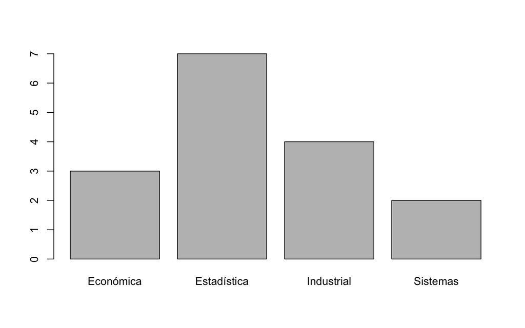

```r
plot(ingresantes$escuela)
```

Sin embargo, uno puede hacer este mismo gráfico del siguiente modo:

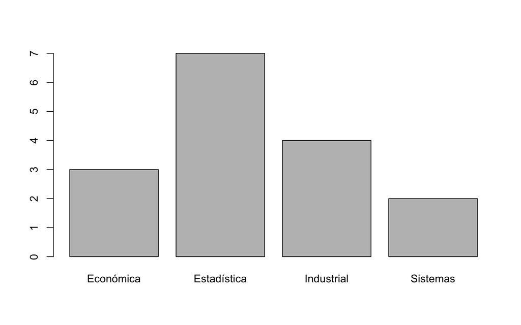

```r
barplot(table(ingresantes$escuela))
```

### 1.4.1 Gráfico de Barras con las frecuencias relativas

```r
frec_abs <- table(ingresantes$escuela)
frec_rel <- frec_abs/sum(frec_abs)
frec_rel
```

```
  Económica Estadística  Industrial    Sistemas
     0.1875      0.4375      0.2500      0.1250
```

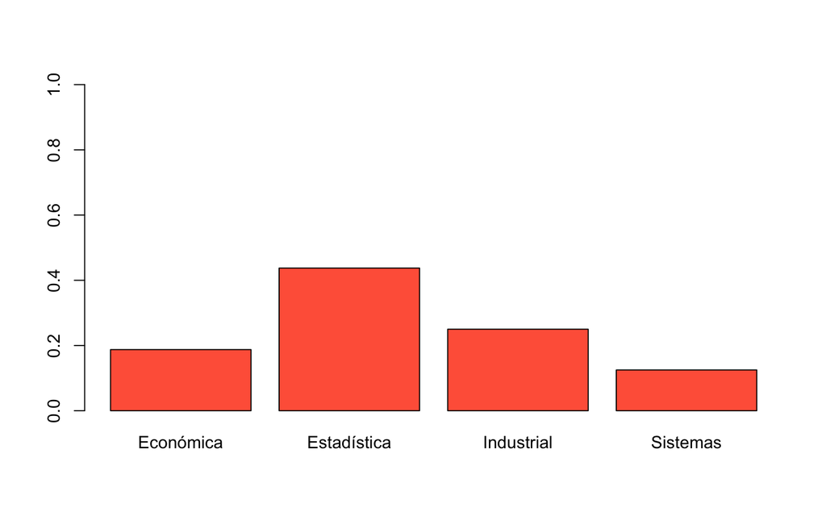

```r
barplot(frec_rel, col = "tomato", ylim = c(0, 1)  # se especifica los límites del eje Y
)
```

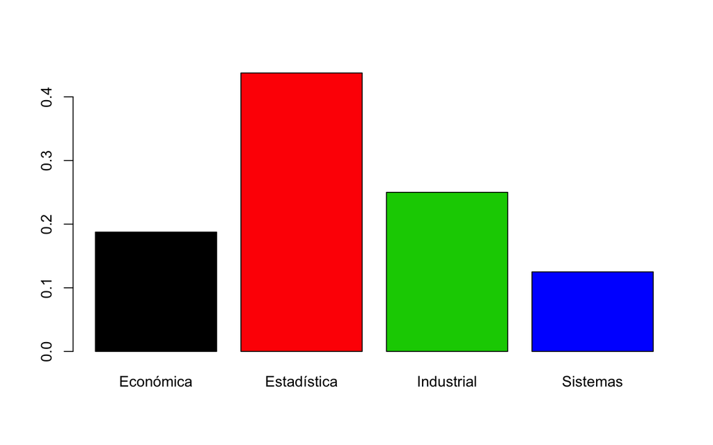

```r
barplot(frec_rel, col = 1:4  # un color para cada barra
)
```

Un aspecto importante de los gráficos de barras es que te permite realizar comparaciones sobre un mismo tipo de contexto. Por ejemplo, considerando el ejemplo anterior de ingresantes, supongamos ahora que la nueva proporción de ingresantes es la siguiente:

```r
# Nueva proporción de ingresantes
frec_rel2 <- c(Económica = 0.1, Estadística = 0.6, Industrial = 0.125, Sistemas = 0.175)
```

En base a lo anterior, se puede construir una matriz con ambas informaciones:

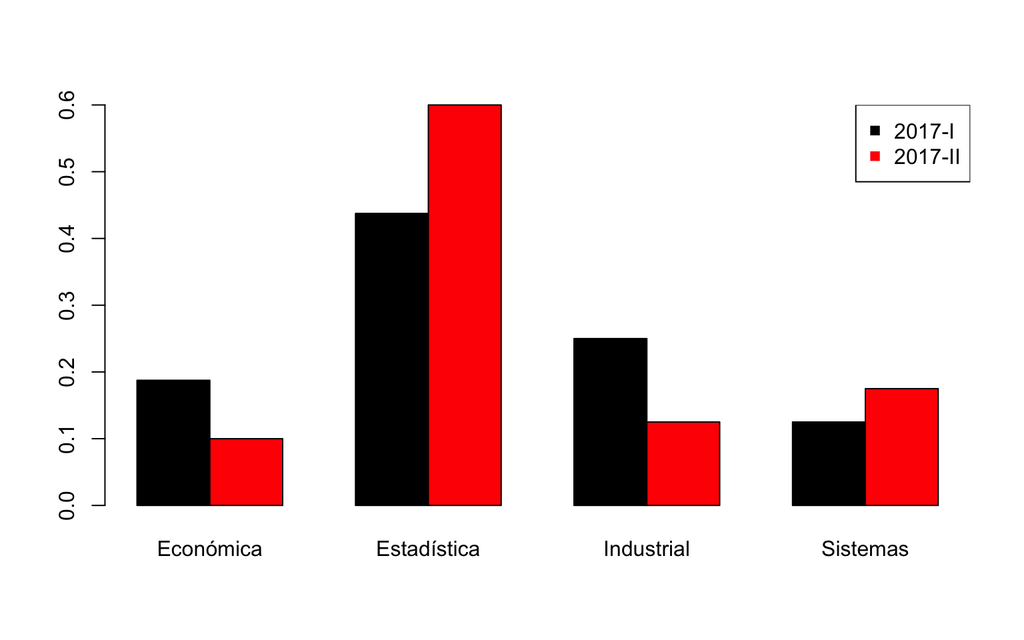

```r
frec_rel_juntas <- rbind(frec_rel, frec_rel2)
rownames(frec_rel_juntas) <- c("2017-I", "2017-II")

# Gráfico de barras para comparación una al lado de otra
barplot(frec_rel_juntas, beside = TRUE, col = 1:2)
legend("topright", legend = rownames(frec_rel_juntas), col = 1:2, pch = 15)
```

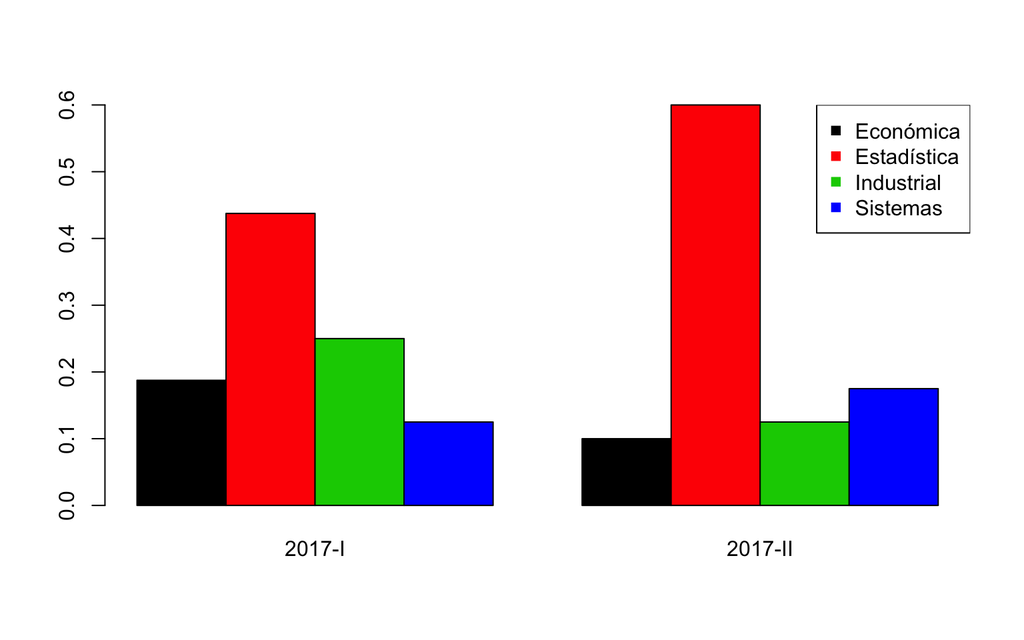

```r
barplot(t(frec_rel_juntas), beside = TRUE, col = 1:4)
legend("topright", legend = colnames(frec_rel_juntas), col = 1:4, pch = 15)
```

## 1.5 Gráfico de Torta o Pie

Representan la frecuencia de las categorías de las variables por medio de un sector circular.

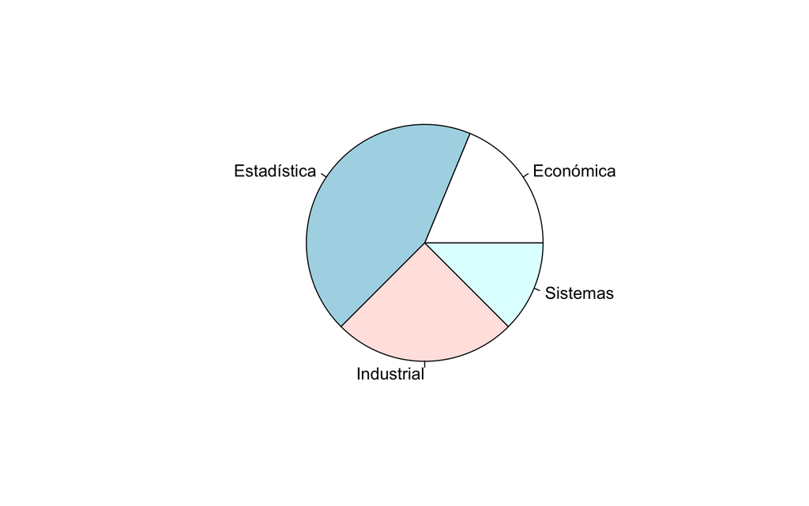

```r
pie(frec_abs)
```

# 2 Gráficos para dos variables

## 2.1 Boxplot con dos variables

Empleado cuando se desea comparar los diagramas de cajas de una variable continua entre las diferentes categorías de la otra variable.

Vamos utilizar la base de datos incorporada en el R sobre las longitudes de sépalos de tres especies de flores iris.

```r
head(iris)
```

```
  Sepal.Length Sepal.Width Petal.Length Petal.Width Species
1          5.1         3.5          1.4         0.2  setosa
2          4.9         3.0          1.4         0.2  setosa
3          4.7         3.2          1.3         0.2  setosa
4          4.6         3.1          1.5         0.2  setosa
5          5.0         3.6          1.4         0.2  setosa
6          5.4         3.9          1.7         0.4  setosa
```

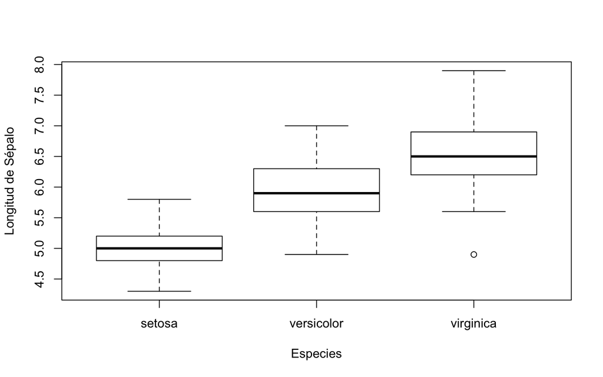

```r
boxplot(Sepal.Length ~ Species, data = iris, ylab = "Longitud de Sépalo", xlab = "Especies")
```

También se puede comparar varios diagramas de cajas de diferentes variables en un mismo gráfico.

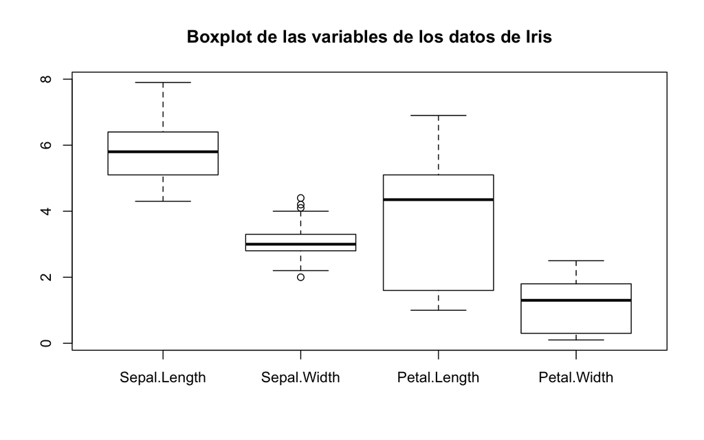

```r
boxplot(iris[, 1:4], main = "Boxplot de las variables de los datos de Iris")
```

## 2.2 Diagrama de dispersión o Scatterplot

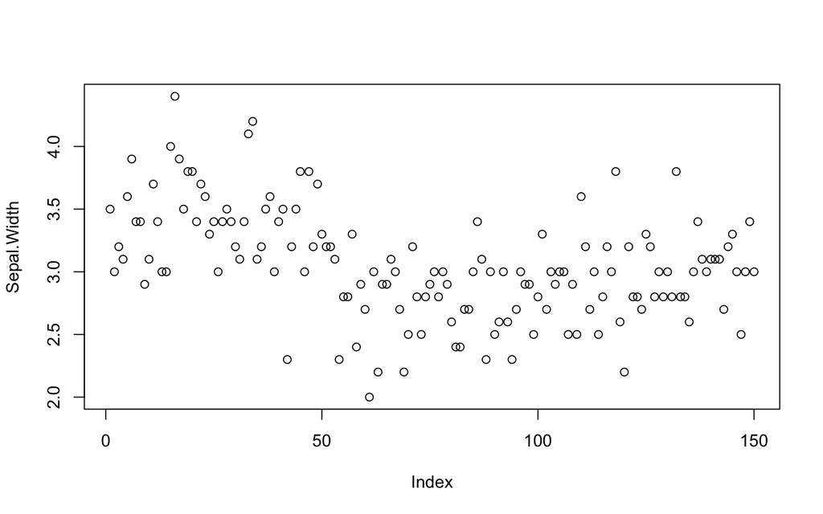

```r
plot(Sepal.Width ~ Sepal.Width, data = iris) # Gráfico por defecto
```

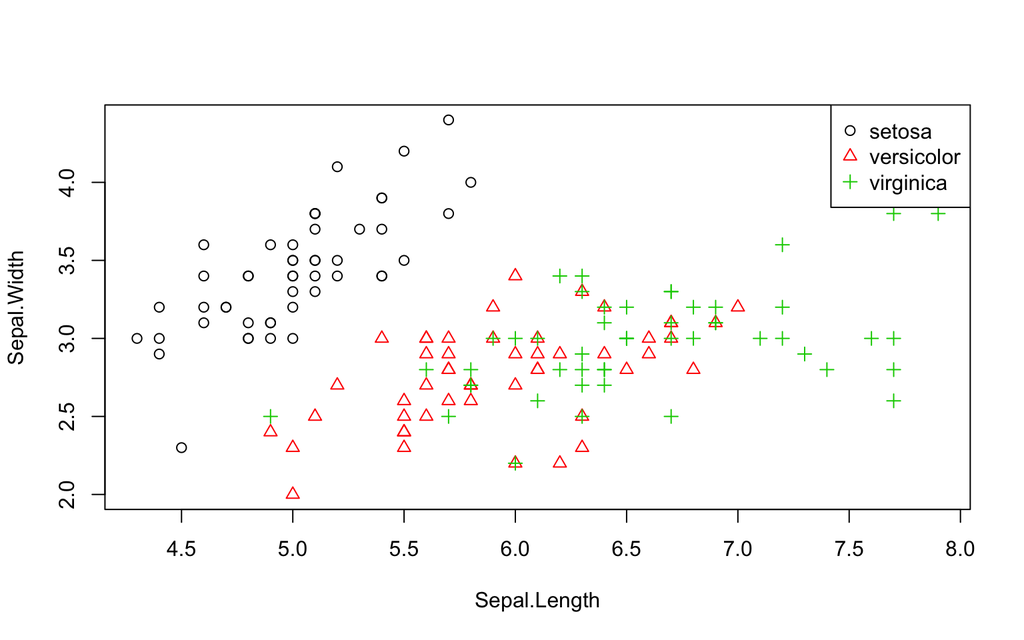

```r
# Perzonalizando el gráfico
plot(Sepal.Width ~ Sepal.Length, data = iris,
     col = Species, # Color según la especie
     pch = as.numeric(Species) # Viñeta según la especie
     )
legend("topright", legend = levels(iris$Species),
       pch = 1:3, col = 1:3)
```